# Population Health Impact and Economic Consequences of Storms

Ben Kesseler

May 24, 2016

# Synopsis

This report examines the U.S. National Oceanic and Atmospheric Administration’s (NOAA) storm database, comparing economic damages, injuries, and fatalities. All analysis was performed at the national level, ignoring specific locations. Individual “events” are not easily determined to assess impacts per “event”, so impacts are considered in aggregate over time.

The most damaging and dangerous event types are tornados, hurricanes/typhoons, thunderstorm winds, lightning, hail, floods, storm surges/tides, rip currents, and heat.

Heat (combining heat and excessive heat) is the most dangerous event in terms of fatalities, and second most dangerous in terms of injuries, while causing little economic damage, so it should be prepared for in warm climates.

Tornados are very damaging in both health and economic terms, and should be prepared for in areas prone to experience them.

Floods are extremely damaging economically, while also impacting health fairly severely, so flood prone regions should take relevant precautions.

Hurricanes and typhoons, perhaps because of the advanced warning usually available, cause less impact to health, while causing the second highest economic damages.

# Data Processing

### Loading the Raw Data

Library packages are loaded for the entire analysis. Code output has been suppressed for this code only.

```r
libraries <- c("plyr",
               "ggplot2",
               "knitr",
               "tools",
               "readr",
               "scales",
               "lubridate",
               "pander",
               "reshape",
               "ggrepel"
               )
sapply(libraries, library, character.only = TRUE)
```

We start with the [NOAA Storm Data](https://d396qusza40orc.cloudfront.net/repdata%2Fdata%2FStormData.csv.bz2) that is archived on the course website and documented [here](https://d396qusza40orc.cloudfront.net/repdata%2Fpeer2_doc%2Fpd01016005curr.pdf) and [here](https://d396qusza40orc.cloudfront.net/repdata%2Fpeer2_doc%2FNCDC%20Storm%20Events-FAQ%20Page.pdf).

```r
source_url <- "https://d396qusza40orc.cloudfront.net/repdata%2Fdata%2FStormData.csv.bz2"
target_local_archive <- "storm_data.csv.bz2"

if (!file.exists(target_local_archive)) {
  download.file(source_url, target_local_archive)
}

storm_data <- read_csv(target_local_archive, na = "NA")
```

### Initial Cleaning

Each row is a very detailed description of a location, event type, injuries, fatalities, and damage, if any. However, actual logical events such as a regional storm or other weather impact might entail many rows, and there is no obvious way to usefully aggregate the rows to logical events.

The analysis covers the entire United States, so location is not important.

As a result, the data will be aggregated by event type at the year level. This will allow the analysis to calculate the impact at an annual level if needed, and across the entire time period for the main analysis.

Once the data is loaded from the .csv.bz2 file, I keep only the year, event type, fatalities, injuries, property damage, and crop damage.

I will also subset the data to any rows with non-0 injuries, fatalities, or economic damage.

```r
storm_data_cleaned <- storm_data[storm_data$FATALITIES > 0  |
                                 storm_data$INJURIES   > 0  |
                                 storm_data$PROPDMG    > 0  |
                                 storm_data$CROPDMG    > 0,
                                 c("BGN_DATE",
                                   "EVTYPE",
                                   "FATALITIES",
                                   "INJURIES",
                                   "PROPDMG",
                                   "PROPDMGEXP",
                                   "CROPDMG",
                                   "CROPDMGEXP"
                                   )
                                 ]

colnames(storm_data_cleaned) <- c("BGN_DATE",
                                  "event_type",
                                  "fatalities",
                                  "injuries",
                                  "property_damage",
                                  "property_damage_exponent",
                                  "crop_damage",
                                  "crop_damage_exponent"
                                  )

storm_data_cleaned$year <- year(as.POSIXct(storm_data_cleaned$BGN_DATE,
                                           format = "%m/%d/%Y"))

mappable_exponents_property <- sum(storm_data_cleaned$property_damage_exponent == "B") +
                               sum(storm_data_cleaned$property_damage_exponent == "M") +
                               sum(storm_data_cleaned$property_damage_exponent == "K") +
                               sum(storm_data_cleaned$property_damage_exponent == "")

mappable_exponents_crop <- sum(storm_data_cleaned$crop_damage_exponent == "B") +
                           sum(storm_data_cleaned$crop_damage_exponent == "M") +
                           sum(storm_data_cleaned$crop_damage_exponent == "K") +
                           sum(storm_data_cleaned$crop_damage_exponent == "")

percent_unmappable_property <- 1 - mappable_exponents_property / nrow(storm_data_cleaned)

percent_unmappable_crop <- 1 - mappable_exponents_crop / nrow(storm_data_cleaned)
```

So 0.102% of property damage records have unmappable exponents, and 0.0177% of crop damage records have unmappable exponents. That’s a very small percent of the records, so treating them as 1 should be reasonable.

I now convert things to a consistent numeric scale, so summation functions will work properly.

```r
scalar_mapping <- data.frame("property_damage_exponent" = c("B","M","K"),
                             "property_damage_numeric_exponent" = c(1000000000,
                                                                    1000000,
                                                                    1000),
                             "crop_damage_exponent" = c("B","M","K"),
                             "crop_damage_numeric_exponent" = c(1000000000,
                                                                1000000,
                                                                1000)
                            )

storm_data_cleaned <- merge(storm_data_cleaned,
                            scalar_mapping[,
                                           c("property_damage_exponent",
                                             "property_damage_numeric_exponent"
                                            )
                                          ],
                            all.x = TRUE)

storm_data_cleaned$property_damage_numeric_exponent[
  is.na(storm_data_cleaned$property_damage_numeric_exponent)] <- 1

storm_data_cleaned <- merge(storm_data_cleaned,
                            scalar_mapping[, c("crop_damage_exponent",
                                               "crop_damage_numeric_exponent"
                                               )], all.x = TRUE)

storm_data_cleaned$crop_damage_numeric_exponent[
  is.na(storm_data_cleaned$crop_damage_numeric_exponent)] <- 1

storm_data_cleaned$property_damage <- storm_data_cleaned$property_damage *
                                      storm_data_cleaned$property_damage_numeric_exponent

storm_data_cleaned$crop_damage <- storm_data_cleaned$crop_damage *
                                  storm_data_cleaned$crop_damage_numeric_exponent

storm_data_cleaned$economic_damage <- storm_data_cleaned$property_damage +
                                      storm_data_cleaned$crop_damage
```

### Data Aggregation

Now I will summarize the data at the level needed for plotting and further exploration - annual by event type.

```r
storm_data_cleaned <- storm_data_cleaned[, c("year",
                                             "event_type",
                                             "fatalities",
                                             "injuries",
                                             "economic_damage")]

storm_data_summary <- aggregate(. ~ year + event_type,
                                data = storm_data_cleaned,
                                FUN = sum)

storm_data_count <- aggregate(fatalities ~ year + event_type,
                              data = storm_data_cleaned,
                              FUN = length)

storm_data_summary <- cbind(storm_data_summary,storm_data_count$fatalities)

storm_data_summary$count <- storm_data_count$fatalities

count_by_year <- aggregate(count ~ year, data = storm_data_summary, FUN = sum)

count_by_year_table <- data.frame("year1" = count_by_year[1:16, 1],
                                  "event_count1" = count_by_year[1:16, 2],
                                  "year2" = count_by_year[17:32, 1],
                                  "event_count2" = count_by_year[17:32, 2],
                                  "year3" = count_by_year[33:48, 1],
                                  "event_count3" = count_by_year[33:48, 2],
                                  "year4" = c(count_by_year[49:62, 1], "", ""),
                                  "event_count4" = c(count_by_year[49:62, 2], "", ""))

panderOptions("table.alignment.default","left")
panderOptions("table.split.table",Inf)
pander(count_by_year_table)
```

| year1 | event_count1 | year2 | event_count2 | year3 | event_count3 | year4 | event_count4 |
| --- | --- | --- | --- | --- | --- | --- | --- |
| 1950 | 201 | 1966 | 423 | 1982 | 1128 | 1998 | 14013 |
| 1951 | 241 | 1967 | 683 | 1983 | 1019 | 1999 | 10609 |
| 1952 | 233 | 1968 | 524 | 1984 | 920 | 2000 | 11508 |
| 1953 | 421 | 1969 | 458 | 1985 | 575 | 2001 | 10298 |
| 1954 | 491 | 1970 | 517 | 1986 | 690 | 2002 | 10432 |
| 1955 | 441 | 1971 | 714 | 1987 | 563 | 2003 | 11015 |
| 1956 | 428 | 1972 | 579 | 1988 | 678 | 2004 | 10484 |
| 1957 | 824 | 1973 | 1026 | 1989 | 791 | 2005 | 10014 |
| 1958 | 543 | 1974 | 884 | 1990 | 986 | 2006 | 11974 |
| 1959 | 505 | 1975 | 748 | 1991 | 879 | 2007 | 11953 |
| 1960 | 556 | 1976 | 707 | 1992 | 990 | 2008 | 17633 |
| 1961 | 627 | 1977 | 693 | 1993 | 5838 | 2009 | 14434 |
| 1962 | 411 | 1978 | 620 | 1994 | 9644 | 2010 | 16019 |
| 1963 | 380 | 1979 | 655 | 1995 | 10457 | 2011 | 20570 |
| 1964 | 594 | 1980 | 728 | 1996 | 10040 |  |  |
| 1965 | 724 | 1981 | 578 | 1997 | 10322 |  |  |

### Event Type Clean-up

Here I will summarize the data by event_type, for the years 1995 and after, and I will remove event types that have no fatalities, injuries, or economic damage, and begin cleaning event types.

```r
storm_data_summary <- storm_data_summary[storm_data_summary$year >= 1995, ]

storm_data_summary <- aggregate(. ~ event_type,
                                data = storm_data_summary[, c("event_type",
                                                              "count",
                                                              "fatalities",
                                                              "injuries",
                                                              "economic_damage")
                                                          ],
                                FUN = sum)

storm_data_summary$event_type <- tolower(storm_data_summary$event_type)

storm_data_summary$event_type <- gsub("[^a-zA-Z0-9 ]"," ",storm_data_summary$event_type)
storm_data_summary$event_type <- gsub("  "," ",storm_data_summary$event_type)

storm_data_summary <- aggregate(. ~ event_type,
                                data = storm_data_summary,
                                FUN = sum)

check_match <- function(f_event_type) {
  f_event_type %in% c("astronomical low tide", "avalanche", "blizzard",
                      "coastal flood", "cold wind chill", "debrisflow",
                      "dense fog", "dense smoke", "drought", "dust devil",
                      "dust storm", "excessive heat", "extreme cold wind chill",
                      "flash flood", "flood", "frost freeze", "funnel cloud",
                      "hail", "heat", "heavy rain", "heavy snow", "high surf",
                      "high wind", "hurricane typhoon", "ice storm",
                      "lake effect snow", "lakeshore flood", "lightning",
                      "marine hail", "marine high wind", "marine strong wind",
                      "marine thunderstorm wind", "rip current", "seiche",
                      "sleet", "storm surge tide", "strong wind",
                      "thunderstorm wind", "tornado", "tropical depression",
                      "tropical storm", "tsunami", "volcanic ash", "water spout",
                      "wildfire", "winter storm", "winter weather"
                      )
  }

storm_data_summary$event_match <- check_match(storm_data_summary$event_type)

initial_matching <- aggregate(. ~ event_match,
                              data = storm_data_summary[, -1],
                              FUN = sum)

percent_unmatched_count <- initial_matching$count[
  initial_matching$event_match == FALSE] / sum(initial_matching$count)

percent_unmatched_injuries <- initial_matching$injuries[
  initial_matching$event_match == FALSE] / sum(initial_matching$injuries)

percent_unmatched_fatalities <- initial_matching$fatalities[
  initial_matching$event_match == FALSE] / sum(initial_matching$fatalities)

percent_unmatched_economic_damage <- initial_matching$economic_damage[initial_matching$event_match == FALSE] /
  sum(initial_matching$economic_damage)
```

After minimal text formatting, I find that when comparing to the expected 48 event types, I’m unable to match 34% of the non-zero events, which account for 19.1% of the economic damage, 12.5% of the injuries, and 14.5% of the fatalities.

This clearly needs some work.

What event types remain?

```r
event_type_list <- data.frame("event_type" = storm_data_summary[1:77, 1],
                              "event_type2" = storm_data_summary[78:154, 1],
                              "event_type3" = storm_data_summary[155:231, 1],
                              "event_type4" = c(storm_data_summary[232:307, 1], ""))

panderOptions("table.alignment.default", "left")
panderOptions("table.split.table",Inf)
pander(event_type_list)
```

| event_type | event_type2 | event_type3 | event_type4 |
| --- | --- | --- | --- |
| agricultural freeze | grass fires | landslide | thunderstorm wind 65mph |
| astronomical high tide | gustnado | landslides | thunderstorm wind 98 mph |
| astronomical low tide | gusty wind | landslump | thunderstorm wind awning |
| avalanche | gusty wind hail | landspout | thunderstorm wind g40 |
| beach erosion | gusty wind hvy rain | late season snow | thunderstorm wind g52 |
| black ice | gusty wind rain | light freezing rain | thunderstorm wind g55 |
| blizzard | gusty winds | light snow | thunderstorm wind g60 |
| blowing dust | hail | light snowfall | thunderstorm wind lightning |
| blowing snow | hail 0 75 | lightning | thunderstorm wind tree |
| breakup flooding | hail 075 | lightning | thunderstorm wind trees |
| brush fire | hail 100 | lightning and heavy rain | thunderstorm winds |
| coastal erosion | hail 125 | lightning and thunderstorm win | thunderstorm winds 63 mph |
| coastal flood | hail 150 | lightning fire | thunderstorm winds and |
| coastal flooding | hail 175 | lightning injury | thunderstorm winds flood |
| coastal flooding erosion | hail 200 | lightning thunderstorm winds | thunderstorm winds g60 |
| coastal storm | hail 275 | lightning wauseon | thunderstorm winds hail |
| coastalstorm | hail 450 | ligntning | thunderstorm winds lightning |
| cold | hail 75 | marine accident | thunderstorm winds53 |
| cold and snow | hail damage | marine hail | thunderstorm windshail |
| cold and wet conditions | hailstorm | marine high wind | thunderstorm windss |
| cold temperature | hard freeze | marine mishap | thunderstorm wins |
| cold wave | hazardous surf | marine strong wind | thunderstorms wind |
| cold weather | heat | marine thunderstorm wind | thunderstorms winds |
| cold wind chill | heat wave | marine tstm wind | thunderstormw |
| dam break | heat wave drought | microburst | thundertorm winds |
| damaging freeze | heavy mix | mixed precip | thunerstorm winds |
| dense fog | heavy rain | mixed precipitation | tidal flooding |
| dense smoke | heavy rain and flood | mud slide | tornado |
| downburst | heavy rain high surf | mud slides urban flooding | tornado f0 |
| drought | heavy rain severe weather | mudslide | tornado f1 |
| drought excessive heat | heavy rains | mudslides | tornado f2 |
| drowning | heavy seas | non severe wind damage | tornado f3 |
| dry microburst | heavy snow | non tstm wind | torrential rainfall |
| dust devil | heavy snow and high winds | other | tropical depression |
| dust devil waterspout | heavy snow and strong winds | rain | tropical storm |
| dust storm | heavy snow high winds flood | rain snow | tropical storm dean |
| early frost | heavy snow ice | rapidly rising water | tropical storm jerry |
| erosion cstl flood | heavy snow shower | record cold | tstm wind |
| excessive heat | heavy snow squalls | record heat | tstm wind g45 |
| excessive rainfall | heavy surf | rip current | tstm wind 40 |
| excessive snow | heavy surf and wind | rip currents | tstm wind 41 |
| excessive wetness | heavy surf coastal flooding | rip currents heavy surf | tstm wind 45 |
| extended cold | heavy surf high surf | river and stream flood | tstm wind 55 |
| extreme cold | heavy swells | river flood | tstm wind 65 |
| extreme cold wind chill | high seas | river flooding | tstm wind and lightning |
| extreme heat | high surf | rock slide | tstm wind damage |
| extreme wind chill | high surf advisory | rogue wave | tstm wind g35 |
| extreme windchill | high swells | rough seas | tstm wind g40 |
| falling snow ice | high water | rough surf | tstm wind g45 |
| flash flood | high waves | rural flood | tstm wind g45 |
| flash flood heavy rain | high wind | seiche | tstm wind g58 |
| flash flood flood | high wind damage | severe thunderstorm | tstm wind hail |
| flash flood street | high wind g40 | severe thunderstorm winds | tstm winds |
| flash flood winds | high winds | severe thunderstorms | tsunami |
| flash flooding | high winds heavy rains | sleet | tunderstorm wind |
| flash floods | hurricane | small hail | typhoon |
| flood | hurricane edouard | snow | unseasonable cold |
| flood heavy rain | hurricane erin | snow and ice | unseasonably cold |
| flood flash | hurricane felix | snow freezing rain | unseasonably warm |
| flood flash flood | hurricane generated swells | snow ice | unseasonably warm and dry |
| flood rain winds | hurricane opal | snow sleet freezing rain | unseasonal rain |
| flooding | hurricane opal high winds | snow squall | urban and small stream floodin |
| flooding heavy rain | hurricane typhoon | snow squalls | urban flood |
| floods | hvy rain | storm force winds | urban flooding |
| fog | hyperthermia exposure | storm surge | urban small stream flood |
| freeze | hypothermia exposure | storm surge tide | urban sml stream fld |
| freezing drizzle | ice | strong wind | volcanic ash |
| freezing fog | ice jam flood minor | strong winds | warm weather |
| freezing rain | ice jam flooding | thundeerstorm winds | waterspout |
| freezing rain snow | ice on road | thunderestorm winds | waterspout tornado |
| freezing spray | ice roads | thundersnow | wet microburst |
| frost | ice storm | thunderstorm | whirlwind |
| frost freeze | ice strong winds | thunderstorm damage to | wild fires |
| funnel cloud | icy roads | thunderstorm wind | wild forest fire |
| glaze | lake effect snow | thunderstorm wind | wild forest fires |
| glaze ice | lake flood | thunderstorm wind 60 mph | wildfire |
| gradient wind | lakeshore flood | thunderstorm wind 65 mph |  |

Now I’m going to clean up some of the obvious event_types errors.

```r
adjust_events <- function(f_event_type) {
  # Check if correct
  if (check_match(f_event_type))
    return(f_event_type)

  # Marine Thunderstorm Wind
  if (grepl("(?=marine)+(?=.*tstm)", f_event_type, perl = TRUE))
    return("marine thunderstorm wind")

  # Coastal Flood
  if (grepl("^(?=(coastal|erosion|tidal))+(?=.*flood)+", f_event_type, perl = TRUE))
    return("coastal flood")

  # Cold Wind Chill
  if (grepl("^(cold|extended)", f_event_type))
    return("cold wind chill")

  # Dense Fog
  if (grepl("(?!freezing)(?=.*fog)+", f_event_type, perl = TRUE))
    return("dense fog")

  # Drought
  if (grepl("^(drought)", f_event_type))
    return("drought")

  # Dust Devil
  if (grepl("^(dust devil)", f_event_type))
    return("dust devil")

  # Extreme Cold Wind Chill
  if (grepl("^(?=(extreme|record))(?=.*(cold|wind))", f_event_type, perl = TRUE))
    return("extreme cold wind chill")

  # Flash Flood
  if (grepl("(flash)", f_event_type))
    return("flash flood")

  if (grepl("(rapidly)", f_event_type)) return("flash flood")

  # Thunderstorm
  if (grepl("^(?!non)(?=.*(thunderstorm|tstm|thune|tund|rtor|deer|restor))+", f_event_type, perl = TRUE))
    return("thunderstorm wind")

  # Lakeshore Flood
  if (grepl("(?=lake)+(?=.*flood)", f_event_type, perl = TRUE))
    return("lakeshore flood")

  # Frost Freeze
  if (grepl("(frost|freeze)", f_event_type))
    return("frost freeze")

  # Hail
  if (grepl("^(?!(gusty))(?=.*hail)+", f_event_type, perl = TRUE))
    return("hail")

  # Excessive Heat
  if (grepl("(?=record)(?=.*heat)", f_event_type, perl = TRUE))
    return("excessive heat")

  # Heat
  if (grepl("(heat|warm)", f_event_type))
    return("heat")

  # High Wind
  if (grepl("^(?=(high|gusty))(?=.*wind)", f_event_type, perl = TRUE))
    return("high wind")

  # Lightning
  if (grepl("(lightn|lignt)", f_event_type))
    return("lightning")

  # Heavy Rain
  if (grepl("(?=(heavy|hvy|exc|torr))(?=.*rain)", f_event_type, perl = TRUE))
    return("heavy rain")

  # Heavy Snow
  if (grepl("^(snow|heavy sn|excessive sn)", f_event_type))
    return("heavy snow")

  # Rip Current
  if (grepl("^(rip)", f_event_type))
    return("rip current")

  # High Surf
  if (grepl("(surf)$", f_event_type))
    return("high surf")

  if (grepl("^(heavy surf)", f_event_type))
    return("high surf")

  # High Swells
  if (grepl("swell", f_event_type))
    return("high swells")

  # Hurricane Typhoon
  if (grepl("(hurricane|typhoon)", f_event_type))
    return("hurricane typhoon")

  # Storm Surge Tide
  if (grepl("surge", f_event_type))
    return("storm surge tide")

  # Strong Wind
  if (grepl("(?=(strong|(storm force)))+(?=.*wind)+", f_event_type, perl = TRUE))
    return("strong wind")

  # High Swells
  if (grepl("(?=(waves| seas))+(?!.*snow)", f_event_type, perl = TRUE))
    return("high swells")

  # Tornado
  if (grepl("^(tornado|landspout)", f_event_type))
    return("tornado")

  # Tropical Storm
  if (grepl("^tropical", f_event_type))
    return("tropical storm")

  # Water Spout
  if (grepl("(spout)", f_event_type))
    return("water spout")

  # Wildfire
  if (grepl("fire", f_event_type))
    return("wildfire")

  # Winter Storm
  if (grepl("(?=winter)+(?=.*storm)+", f_event_type, perl = TRUE))
    return("winter storm")

  # Winter Weather
  if (grepl("^(winter|wintry)", f_event_type))
    return("winter weather")

  # Flood
  if (grepl("(flood|fld)", f_event_type))
    return("flood")
}

adjusted_events <- sapply(storm_data_summary$event_type, adjust_events)

for (i in 1:nrow(storm_data_summary)) {
  if (is.null(adjusted_events[[i]])) {"delete"
    } else {
      storm_data_summary$event_type[i] <- adjusted_events[[i]]
    }
}

storm_data_summary <- aggregate(. ~ event_type,
  data = storm_data_summary[storm_data_summary$event_type != "delete", ],
  FUN = sum)
```

Things are a bit more clear now. Let’s see how these align to the 48 event types now.

```r
storm_data_summary$event_match <- check_match(storm_data_summary$event_type)

final_matching <- aggregate(. ~ event_match,
                            data = storm_data_summary[, -1],
                            FUN = sum)

percent_unmatched_count_final <- final_matching$count[
  final_matching$event_match == FALSE] / sum(final_matching$count)

percent_unmatched_injuries_final <- final_matching$injuries[
  final_matching$event_match == FALSE] / sum(final_matching$injuries)

percent_unmatched_fatalities_final <- final_matching$fatalities[
  final_matching$event_match == FALSE] / sum(final_matching$fatalities)

percent_unmatched_economic_damage_final <- final_matching$economic_damage[
  final_matching$event_match == FALSE] / sum(final_matching$economic_damage)
```

After more aggressive remapping, I find that when comparing to the expected 48 event types, I’m unable to match 0.359% of the non-zero events, which account for 0.135% of the economic damage, 0.863% of the injuries, and 1.43% of the fatalities.

That’s an acceptable error rate.

A little text adjustment for the final plotting and analysis section.

```r
storm_data_summary$event_type <- toTitleCase(storm_data_summary$event_type)
storm_data_summary$event_type[storm_data_summary$event_type == "Cold Wind Chill"] <- "Cold/Wind Chill"
storm_data_summary$event_type[storm_data_summary$event_type == "Extreme Cold Wind Chill"] <- "Extreme Cold/Wind Chill"
storm_data_summary$event_type[storm_data_summary$event_type == "Frost Freeze"] <- "Frost/Freeze"
storm_data_summary$event_type[storm_data_summary$event_type == "Hurricane Typhoon"] <- "Hurricane (Typhoon)"
storm_data_summary$event_type[storm_data_summary$event_type == "Lake Effect Snow"] <- "Lake-Effect Snow"
storm_data_summary$event_type[storm_data_summary$event_type == "Storm Surge Tide"] <- "Storm Surge/Tide"
```

I’m going to prepare my plots here, so the results section stays clean.

```r
storm_data_final <- storm_data_summary[storm_data_summary$event_match == TRUE, ]

storm_data_final$combined_health <- storm_data_final$injuries +
                                    storm_data_final$fatalities

storm_data_plot1 <- storm_data_final[storm_data_final$combined_health > 0, ]

storm_data_plot1$event_type <- factor(storm_data_plot1$event_type,
                                      levels = storm_data_plot1$event_type[
                                        order(storm_data_plot1$combined_health,
                                              decreasing = TRUE)])

storm_data_plot1$foi_ratio <- storm_data_plot1$fatalities / storm_data_plot1$injuries

storm_data_plot1 <- head(storm_data_plot1[order(-storm_data_plot1$combined_health), ], 20)

Figure_1 <- ggplot(data = storm_data_plot1, aes(x = injuries,
                                                y = fatalities,
                                                fill = foi_ratio)) +
  geom_point(aes(fill = foi_ratio), shape = 21, size = 2) +
  theme_bw() +
  ggtitle("Injuries vs Fatalities by Event Type") +
  xlab("Injuries") +
  ylab("Fatalities") +
  scale_fill_gradient("Fatalities over Injuries", low = "green", high = "red") +
  geom_label_repel(data = subset(storm_data_plot1,
                                 (injuries > 1400 | fatalities > 195)),
                   aes(label = event_type)) +
  theme(legend.position = c(0.94, 0.1),
        legend.direction = "vertical") +
  guides(fill = guide_colorbar(title.position = "left", title.theme = element_text(size=10, angle = 90)))
```

```r
storm_data_plot2 <- storm_data_final[storm_data_final$economic_damage > 0, ]

storm_data_plot2$event_type <- factor(storm_data_plot2$event_type,
                                      levels = storm_data_plot2$event_type[
                                        order(storm_data_plot2$economic_damage,
                                              decreasing = TRUE)])

storm_data_plot2 <- head(storm_data_plot2[
  order(-storm_data_plot2$economic_damage), ], 20)

storm_data_plot2$economic_damage <- storm_data_plot2$economic_damage / 1000000000

Figure_2 <- ggplot(data = storm_data_plot2,
                   aes(x = event_type, y = economic_damage, fill = economic_damage)) +
  geom_bar(stat = "identity") +
  theme_bw() +
  coord_flip() +
  ggtitle("Economic Damage by Event Type") +
  xlab("Event Types") +
  ylab("Economic Damage in Billions of USD (unadjusted)") +
  scale_fill_gradient("Billions USD", low = "green", high="dark green") +
  theme(legend.position = c(0.9, 0.9),
        legend.direction = "horizontal",
        panel.grid.major.y = element_line(colour = "#ffffff")) +
  guides(fill = guide_colorbar(title.position = "top", title.theme = element_text(size=10, angle = 0)))
```

```r
storm_data_plot3 <- storm_data_final[, c("event_type", "fatalities", "injuries",
                                         "economic_damage", "combined_health")]

storm_data_plot3 <- head(storm_data_plot3[order(-storm_data_plot3$combined_health), ], 20)

storm_data_plot3$foi_ratio <- storm_data_plot3$fatalities / storm_data_plot3$injuries

storm_data_plot3$economic_damage <- log10(storm_data_plot3$economic_damage)
storm_data_plot3$combined_health <- log10(storm_data_plot3$combined_health)

Figure_3 <- ggplot(data = storm_data_plot3, aes(x = economic_damage,
                                                  y = combined_health,
                                                 fill = foi_ratio)) +
  geom_point(aes(fill = foi_ratio), shape = 21, size = 5) +
  theme_bw() +
  scale_fill_gradient("Fatalities over Injuries", low = "green", high = "red") +
  ggtitle("Economic Damage vs Combined Health Impact by Event Type") +
  xlab("Economic Damage (USD log10 scale)") +
  ylab("Combined Health Impact (log10 scale)") +
  geom_label_repel(aes(label = event_type)) +
  theme(legend.position = c(0.06, 0.9),
        legend.direction = "vertical") +
  guides(fill = guide_colorbar(title.position = "left", title.theme = element_text(size=10, angle = 90)))
```

# Results

## Fatality, Injury, and Economic Damage Sources

I need to examine the distribution of injuries, fatalaties, and economic damage by the event types present in this data.

I’ll be using top 20 event types (based on the variables being analyzed) for these analyses, to make things easier to work with.

Note, all of the preparation for these plots occurred above, in the data processing section, but the plots are presented and discussed here.

## Figure 1 - Injuries & Fatalities Exploration

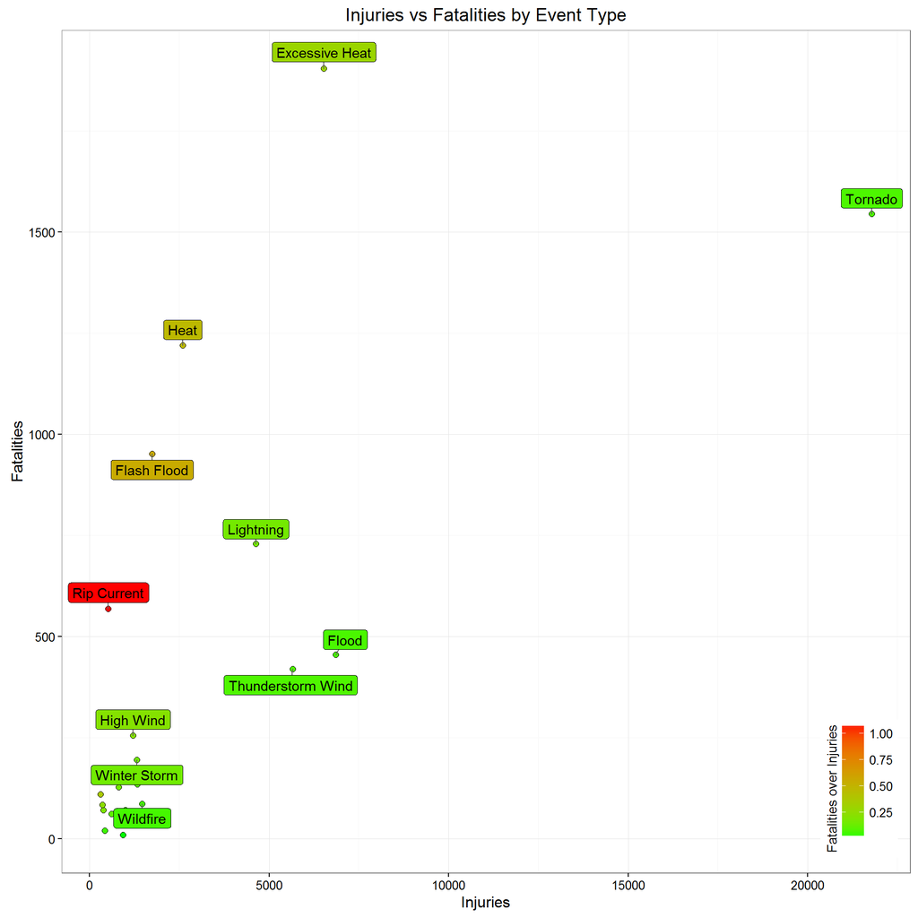

This plot shows fatalities vs injuries for the top 20 events by combined health impact. Points and labels are colored by the ratio of fatalities to injuries.

```r
Figure_1
```

Fatalities and injuries seem to be correlated, although Tornados cause signifigantly more injuries than any other event. However, Rip Currents are more dangerous to life, independent of overall risk of encountering the events.

### Figure 2 - Economic Damage Exploration

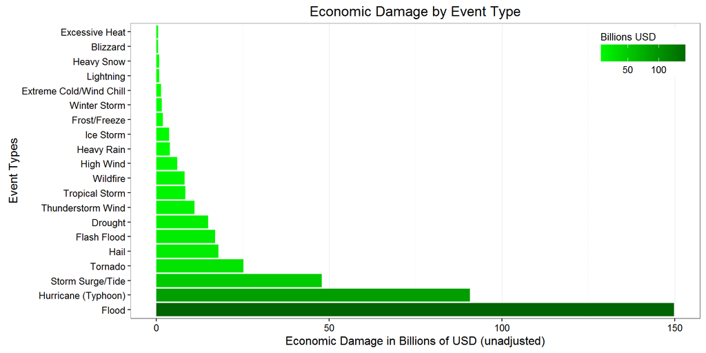

This plot shows economic damage in billions of USD, for the top 20 event types by economic damage. Bars are colored by the economic damage. The values have not been adjusted for inflation.

```r
Figure_2
```

**Floods, hurricanes/typhoons, storm surges/tides, and tornados are the most damaging events, economically.**

Flood may be somewhat overstated as all flood events are required to have a damage statement, even if an estimate.

### Figure 3 - Economic Damage vs Combined Health Impact

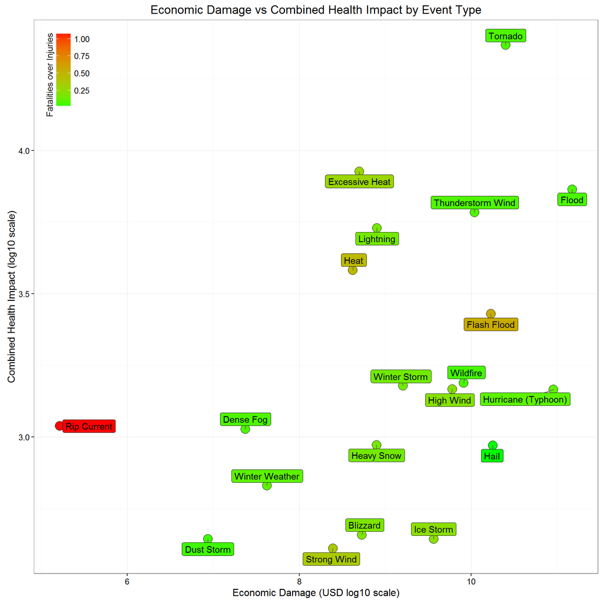

This plot shows economic damage vs combined health impact (injuries + fatalities), both on a log10 scale, for the top 20 event types by combined health impact. Points and labels are colored by the ratio of fatalities to injuries, before log10 conversion.

```r
Figure_3
```

**Event types are fairly evenly distributed on a log scale, in terms of both economic damage and combined health impact.**

Rip Current still stands out as a very dangerous event, with extremely small prevalence and near-zero economic impact.

# Further Exploration

### Location Analysis

A further analysis could plot injuries, fatalities, and economic damage as a density plot over the United States, by utilizing the latitude and longitude present in the data.

### Time Analysis

After subsetting to post-1994 data to ensure consistent reporting methods, events and damages could be compared over time, to determine if any events are occuring more frequently, or are causing more impact, over time.

### Logical Event Combinations

Some events are logically connected, such as “heat” and “excessive heat”, and might be combined to create a smaller set with more value for communication to the public, as the event types are currently defined for the meteorological community.

# Additional Resources

- [Github Repository](https://github.com/bkkesseler/DSS5-ReproducibleResearch-Week4)

# Session Information

- Toshiba Chromeboook 2 (2015)
- 1.70 GHz Intel Celeron 3215U
- 4GB RAM
- RStudio Version 0.99.893